# Manifold Learning

### **NOTES ON STATISTICS, PROBABILITY and MATHEMATICS**

### Statistical Learning or Non-Linear Dimension-Reduction Algorithms:

From this [MMDS lecture](https://youtu.be/ddhbjCLIjho), an this [parallel presentation](https://youtu.be/kTJoFLcdtn8).

Manifold learning addresses the problem of high-dimensional data. Dimensionality reduction improves computational analysis, and it is beneficial as long as it preserves most of the important information.

An $n = 698$ dataset of $64 \times 64$ gray images of faces, where the faces only vary in terms of the head moving up and down or left to right, a 2D manifold is defined. In this case the different orientations are shown on an isomap embedding:

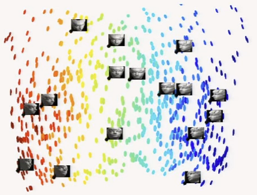

with each ellipse showing one of the $698$ faces.

##### Steps in the process:

1. Input data iid points $p_1,p_2,\dots,p_n.$
2. Construct neighborhood graph where $p,p'$ are neighbors iff $\Vert p - p' \Vert^2\leq \epsilon.$ Neighbors will have an edge connecting them.
3. Represent the graph as an $n \times n$ matrix with leading eigenvectors as the coordinates $\phi(p_{1:n}).$ The only information taken into consideration is the distances between neighbors.
4. Construct embedding (This step varies between algorithms):

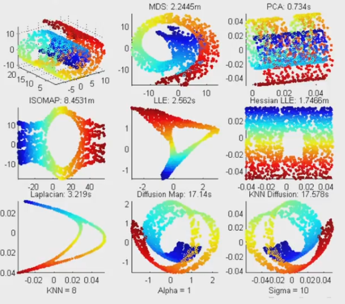

The idea is that PCA makes the implicit assumption that the manifold is a linear space, projecting onto it. However this is not the case in high-dimensional datasets, motivating the topic - i.e. non-linear dimensionality reduction or manifold learning.

##### Types of embeddings:

- Local Linear Embedding
- Laplacian Eigenmap
- Diffusion Map
- Linear Tangent Space Alignment
- Isomap / MDS

Local linear embedding expresses every point as a linear combination of its neighbors (it’s a weighted average).

Diffusion Map and Laplacian Eigenmap work by defining a random walk on a set of points and do an eigen decomposition of the random walk.

Linear Tangent Space Alignment do local PCA, and patch them together.

Isomaps preserve the geodesics, i.e. the distances on the manifold.

The question that arises, then, is which of these embeddings is “correct.”

One type of diffusion maps is the LAPLACIAN EIGENMAPS:

1. Construct similarity matrix:

$$S = \left [ S_{pp'}\right
]_{p,p'} \in \mathcal D$$

with $S_{pp'}= \exp\left(-\frac{1}{2} \Vert p - p' \Vert^2 \right)$ iff $p,p'$ are neighbors.

2. Construct a Laplacian matrix

$$L = I - T^{-1}S$$

with $T=\text{diag}(S1).$

3. Calculate smallest eigenvectors of $L,$ labelled $\psi^{1,\dots,m}.$
4. Cordinates of $p\in \mathcal D$ are $\psi^1(p),\psi^2(p),\dots,\psi^m(p).$

#### Example of Graph Laplacian in R:

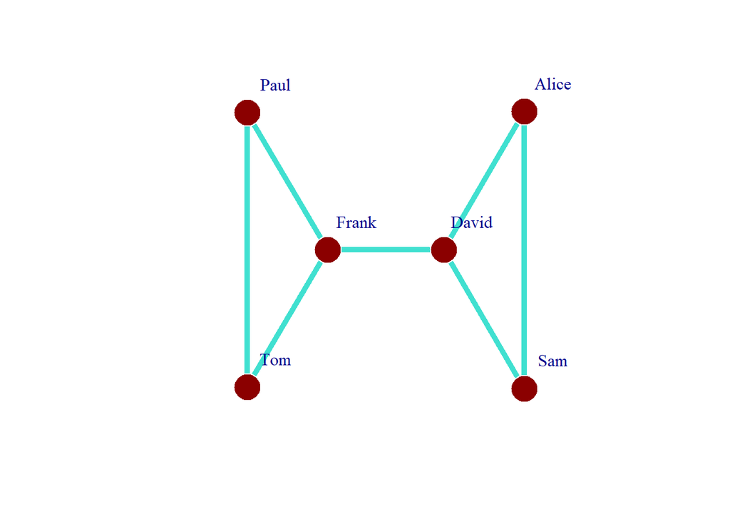

```r
require(igraph)

g <- graph(edges=c('Alice','Sam','Sam','David','David','Alice','Frank','David','Frank','Paul','Paul','Tom','Tom','Frank'), directed = FALSE)
igraph_options(plot.layout=layout_nicely, vertex.size=20, vertex.frame.color=F, edge.width=5, edge.color='turquoise', vertex.label.dist=4, vertex.color='red4')
plot(g)
```

```r
laplacian_matrix(g)
```

```
## 6 x 6 sparse Matrix of class "dgCMatrix"
##       Alice Sam David Frank Paul Tom
## Alice     2  -1    -1     .    .   .
## Sam      -1   2    -1     .    .   .
## David    -1  -1     3    -1    .   .
## Frank     .   .    -1     3   -1  -1
## Paul      .   .     .    -1    2  -1
## Tom       .   .     .    -1   -1   2
```

Reading out the output:

From the linear algebra explanation by Professor Strang in [here](https://youtu.be/cxTmmasBiC8), and [this post](https://math.stackexchange.com/a/4095061/152225).